# Przykładowe rozwiązanie

Aleksandra Brodecka

8 października 2017

Biblioteki:

# Wstęp:

Rozkodujmy zmienne nominalne na zmienne 0-1:

```r
train$race <- as.factor(train$race)
train$race_o <- as.factor(train$race_o)
train$career_c.x <- as.factor(train$career_c.x)
train$career_c.y <- as.factor(train$career_c.x)
train$goal <- as.factor(train$goal)
train$wave <- as.factor(train$wave)
train$condtn <- as.factor(train$condtn)

test$race <- as.factor(test$race)
test$race_o <- as.factor(test$race_o)
test$career_c.x <- as.factor(test$career_c.x)
test$career_c.y <- as.factor(test$career_c.x)
test$goal <- as.factor(test$goal)
test$wave <- as.factor(test$wave)
test$condtn <- as.factor(test$condtn)

train.new  <- model.matrix(~.-1 , data=train) %>% data.frame() %>%
                            dplyr::select(-c(race2,career_c.x2, race_o2,career_c.y2,
                                             wave2, condtn1))

test.new  <- model.matrix(~.-1 , data=test) %>% data.frame() %>%
  dplyr::select(-c(race2,career_c.x2, race_o2,career_c.y2,
                                             wave2, condtn1))
```

# Regresja logistyczna wraz z kryterium BIC

```r
logit <- glm(dec ~ ., family=binomial(link="logit"), data=train.new)
logit.bic <- step(logit, direction = "backward", k = log(nrow(train.new)), trace = 0)
summary(logit.bic)
```

```
##
## Call:
## glm(formula = dec ~ race6 + career_c.x8 + career_c.x10 + career_c.x13 +
##     shar1_1 + wave3 + wave12 + wave21 + goal2 + goal6 + go_out +
##     tvsports + exercise, family = binomial(link = "logit"), data = train.new)
##
## Deviance Residuals:
##     Min       1Q   Median       3Q      Max
## -1.7579  -1.1018  -0.7395   1.1554   2.3895
##
## Coefficients:
##               Estimate Std. Error z value Pr(>|z|)
## (Intercept)   0.059120   0.163804   0.361 0.718158
## race6         0.733518   0.169242   4.334 1.46e-05 ***
## career_c.x8  -2.530545   1.044411  -2.423 0.015395 *
## career_c.x10 -0.979813   0.243122  -4.030 5.57e-05 ***
## career_c.x13 -1.318528   0.466942  -2.824 0.004747 **
## shar1_1       0.018111   0.006204   2.919 0.003508 **
## wave3        -1.134733   0.269459  -4.211 2.54e-05 ***
## wave12       -0.866457   0.189474  -4.573 4.81e-06 ***
## wave21       -0.694908   0.128597  -5.404 6.53e-08 ***
## goal2        -0.261489   0.089773  -2.913 0.003582 **
## goal6        -0.639629   0.217585  -2.940 0.003286 **
## go_out       -0.136207   0.041043  -3.319 0.000905 ***
## tvsports     -0.071572   0.017008  -4.208 2.57e-05 ***
## exercise      0.074873   0.018187   4.117 3.84e-05 ***
## ---
## Signif. codes:  0 '***' 0.001 '**' 0.01 '*' 0.05 '.' 0.1 ' ' 1
##
## (Dispersion parameter for binomial family taken to be 1)
##
##     Null deviance: 3295.1  on 2389  degrees of freedom
## Residual deviance: 3134.0  on 2376  degrees of freedom
## AIC: 3162
##
## Number of Fisher Scoring iterations: 4
```

Widzimy, że zmienne takie jak:

- race6, shar1_1, exercise mają dodatni współczynnik oszacowania zatem przy wzroście zmiennych o 1, szansa zdarzenia rośnie
- dla pozostałych zmiennych mamy odwrotną sytację, tytaj szansa zdarzenia spada.

Dokładne oszacowania ilorazu szans:

```r
exp(coef(logit.bic))
```

```
##  (Intercept)        race6  career_c.x8 career_c.x10 career_c.x13
##    1.0609030    2.0823929    0.0796156    0.3753815    0.2675287
##      shar1_1        wave3       wave12       wave21        goal2
##    1.0182763    0.3215078    0.4204386    0.4991203    0.7699044
##        goal6       go_out     tvsports     exercise
##    0.5274883    0.8726619    0.9309289    1.0777476
```

Narysujmy wykres prawdopodobieństwa zdarzenia:

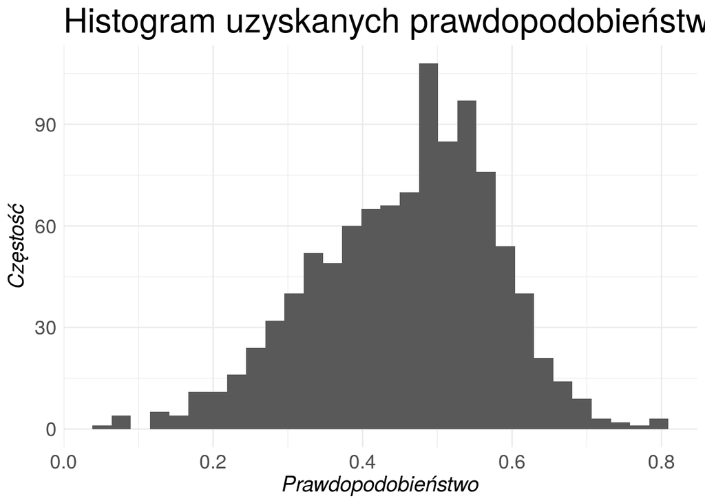

```r
probs <- predict(logit.bic, test.new,type='response')

qplot(probs) + ggtitle("Histogram uzyskanych prawdopodobieństw przynależności do klasy 1") +
  labs(y = "Częstość", x = "Prawdopodobieństwo") + theme_minimal() +
  theme(axis.title.x = element_text(size = 15, angle = 0, face = "italic"),
        axis.title.y = element_text(size = 15, angle = 90, face = "italic")) +
  theme(legend.title = element_text(size = 14, face = "bold")) +
  theme(legend.text = element_text(colour = "black", size = 12)) +
  guides(color = guide_legend(keywidth = 2, keyheight = 2)) + theme(title = element_text(size = 20)) + theme(axis.text= element_text(size = 14))
```

```r
class <- ifelse(probs > 0.5,1,0)
c1 <- check_class(test.new$dec, class)
c1
```

```
##  % popr. odp.       czułość      precyzja specyficzność
##     0.5874878     0.4838013     0.5503686     0.6120130
```

# Regresja logistyczna wraz z pomocą LASSO

```r
cv.glmmod <- cv.glmnet(y = as.factor(train$dec),
            x= as.matrix(train.new[,-1]), alpha=1, family="binomial")

#Wybieramy parametr lambda
(best.lambda.se <- cv.glmmod$lambda.1se)
```

```
## [1] 0.01579802
```

```r
logit.lasso.lambda <- glmnet(y = as.factor(train.new$dec), x= as.matrix(train.new[,-1]),
                             alpha=1, family="binomial", lambda = best.lambda.se)

coef(cv.glmmod, s = best.lambda.se)
```

```
## 83 x 1 sparse Matrix of class "dgCMatrix"
##                          1
## (Intercept)  -6.303956e-02
## condtn2       .
## order         .
## race3         .
## race4         .
## race6         3.484484e-01
## age           .
## int_corr      .
## career_c.x3   .
## career_c.x4   .
## career_c.x5   .
## career_c.x6   .
## career_c.x7   .
## career_c.x8  -7.136556e-01
## career_c.x9   .
## career_c.x10 -3.948970e-01
## career_c.x13 -4.728363e-01
## career_c.x14  .
## career_c.x15  .
## career_c.x17 -1.146802e-01
## income        9.172670e-07
## attr1_1       .
## sinc1_1       5.454128e-03
## intel1_1      .
## fun1_1       -9.134911e-04
## amb1_1        .
## shar1_1       5.595608e-03
## wave3        -4.076564e-01
## wave4         .
## wave5         .
## wave10        .
## wave11        4.845131e-02
## wave12       -3.377052e-01
## wave13        .
## wave14        .
## wave15        .
## wave16        .
## wave17        .
```

[output cut: 30 more lines]

```
## exercise      2.623738e-02
## dining        .
## museums       .
## art           .
## hiking        .
## gaming        .
## clubbing      1.720380e-02
## reading       .
## tv           -8.669740e-03
## theater       .
## movies       -1.579170e-02
## concerts      .
## music         .
## shopping      .
## yoga          .
```

W przypadku skorzystania z LASSO otrzymujemy:

- race6, income, sinc1_1, shar1_1 ,wave11, wave19, wave20, race_o6, exercise, clubbing mają dodatni współczynnik oszacowania zatem przy wzroście zmiennych o 1, szansa zdarzenia rośnie. Widać tu ciekawą zależność: mężczyźni szukają kobiet, które mają wspólne zainteresowania i są szczere a z drugiej strony wybierają takie, które są zainteresowane clubbingiem i ćwiczeniami, czyżby to były główne zainteresowania mężczyzn? ;)

Dokładne ilorazy szans:

```r
is <- exp(coef(cv.glmmod, s = best.lambda.se))
names <- rownames(is)
data.frame(coef = names[which(is!=1)], io = round(is[is!=1], 2))
```

```
##            coef   io
## 1   (Intercept) 0.94
## 2         race6 1.42
## 3   career_c.x8 0.49
## 4  career_c.x10 0.67
## 5  career_c.x13 0.62
## 6  career_c.x17 0.89
## 7        income 1.00
## 8       sinc1_1 1.01
## 9        fun1_1 1.00
## 10      shar1_1 1.01
## 11        wave3 0.67
## 12       wave11 1.05
## 13       wave12 0.71
## 14       wave19 1.08
## 15       wave20 1.21
## 16       wave21 0.64
## 17      race_o6 1.03
## 18        goal2 0.91
## 19        goal6 0.93
## 20       go_out 0.93
## 21  career_c.y8 0.99
## 22 career_c.y10 0.96
## 23 career_c.y13 0.99
## 24 career_c.y17 1.00
## 25     tvsports 0.97
## 26     exercise 1.03
## 27     clubbing 1.02
## 28           tv 0.99
## 29       movies 0.98
```

Przewidujemy prawdopodobieństwo zdarzenia:

```r
lasso.prob <- predict(cv.glmmod,newx = as.matrix(test.new[,-1]),
                      s=best.lambda.se,type="response")
```

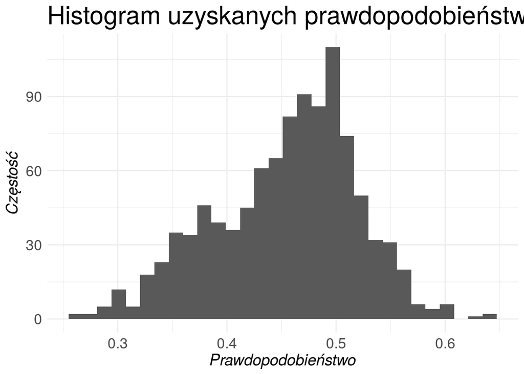

```r
qplot(lasso.prob) + ggtitle("Histogram uzyskanych prawdopodobieństw przynależności do klasy 1") +
  labs(y = "Częstość", x = "Prawdopodobieństwo") + theme_minimal() +
  theme(axis.title.x = element_text(size = 15, angle = 0, face = "italic"),
        axis.title.y = element_text(size = 15, angle = 90, face = "italic")) +
  theme(legend.title = element_text(size = 14, face = "bold")) +
  theme(legend.text = element_text(colour = "black", size = 12)) +
  guides(color = guide_legend(keywidth = 2, keyheight = 2)) + theme(title = element_text(size = 20)) + theme(axis.text= element_text(size = 14))
```

```r
class <- ifelse(lasso.prob > 0.5,1,0)
c2 <- check_class(test.new$dec, class)
c2
```

```
##  % popr. odp.       czułość      precyzja specyficzność
##     0.5992180     0.3261339     0.6064257     0.5968992
```

# Klasyfikacja za pomocą drzew:

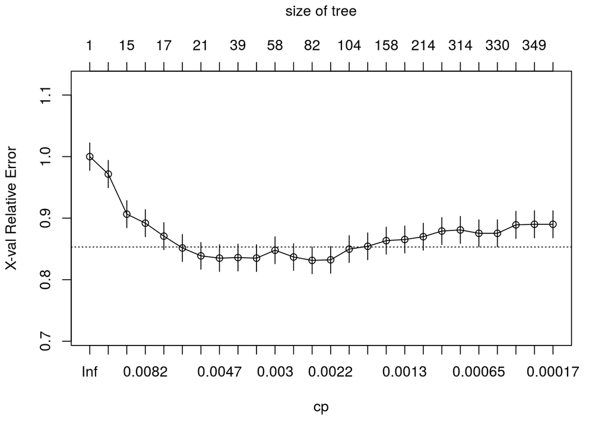

```r
set.seed(555)
tree.tmp <- rpart(factor(dec)~., data = train.new, cp = 0.0001, minsplit = 5)
plotcp(tree.tmp)
```

```r
printcp(tree.tmp)
```

```
##
## Classification tree:
## rpart(formula = factor(dec) ~ ., data = train.new, cp = 1e-04,
##     minsplit = 5)
##
## Variables actually used in tree construction:
##  [1] age         amb1_1      art         attr1_1     career_c.x4
##  [6] career_c.x5 career_c.x6 career_c.x7 career_c.x9 clubbing
## [11] concerts    condtn2     date        dining      exercise
## [16] fun1_1      gaming      goal2       go_out      hiking
## [21] income      income_o    int_corr    intel1_1    movies
## [26] music       order       race3       race4       race6
## [31] reading     shar1_1     shopping    sinc1_1     sports
## [36] theater     tv          tvsports    wave11      wave12
## [41] wave15      wave19      wave20      wave21      wave3
```

[output cut: 33 more lines]

```r
cp.cv = 0.00229148 # cp metodą krosswalidacji
cp.1se = 0.021745 + 0.00229148 #cp metodą 1se

n <- nrow(train.new)
n1 <- floor(n*0.7)
lp <- 300
zmienne <- c("1")
zmienne.bezpowt <- c("1")
m <- 0
cp_opt <- cp.cv
for(i in 1:lp){
  m <- m + 1
  pseud <- sample(1:n, n1)
  tmp.tree <- rpart(factor(dec)~., data = train.new[pseud,], cp = cp_opt, minsplit = 5)
  zmienne <- c(zmienne, tmp.tree$frame$var)
  zmTMP <- sort(tmp.tree$frame$var) %>% as.character()
  zmTMP <- zmTMP[zmTMP!="<leaf>"]
  zmTMP.bezpowt <- c("1")
  for(i in 2:length(zmTMP)){
    if(zmTMP[i]!= zmTMP[i-1])
      zmTMP.bezpowt <- c(zmTMP.bezpowt, as.character(zmTMP[i]))
  }

  zmienne.bezpowt <- c(zmienne.bezpowt, zmTMP.bezpowt)
}

names(which(table(zmienne.bezpowt)[-1] > 200))
```

```
##  [1] "amb1_1"      "art"         "attr1_1"     "career_c.x7" "clubbing"
##  [6] "concerts"    "date"        "dining"      "exercise"    "fun1_1"
## [11] "gaming"      "go_out"      "hiking"      "income"      "income_o"
## [16] "int_corr"    "intel1_1"    "movies"      "museums"     "music"
## [21] "order"       "race4"       "race6"       "reading"     "shar1_1"
## [26] "shopping"    "sinc1_1"     "sports"      "theater"     "tv"
## [31] "tvsports"    "wave21"      "yoga"
```

## Lasy losowe

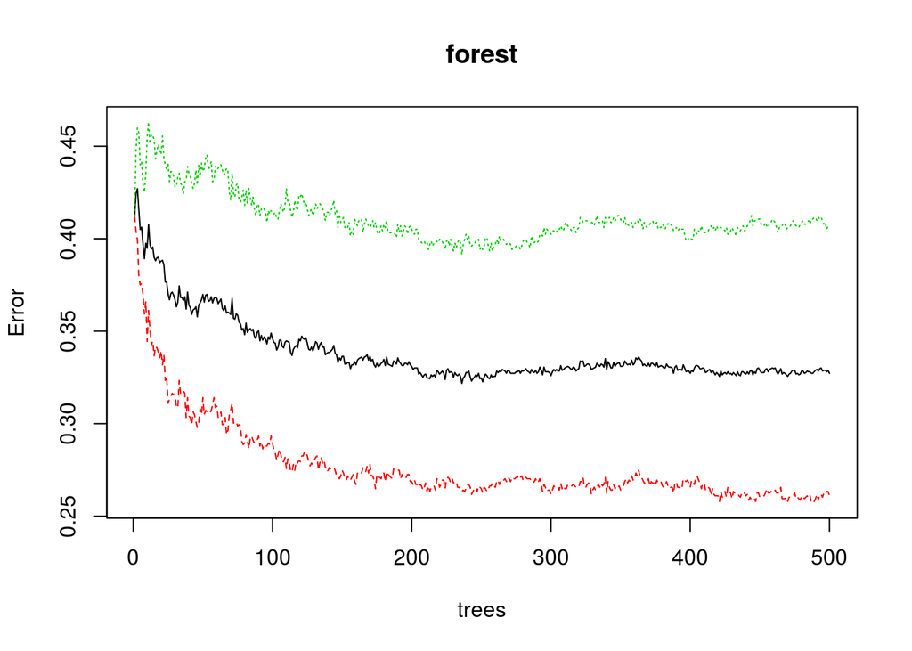

```r
forest <- randomForest(as.factor(dec)~., data = train.new,
                       localImp = TRUE)
plot(forest)
```

Dostaliśmy trzy linie ponieważ czarna odpowiada za OOB a kolorowe za błędy w klasach.

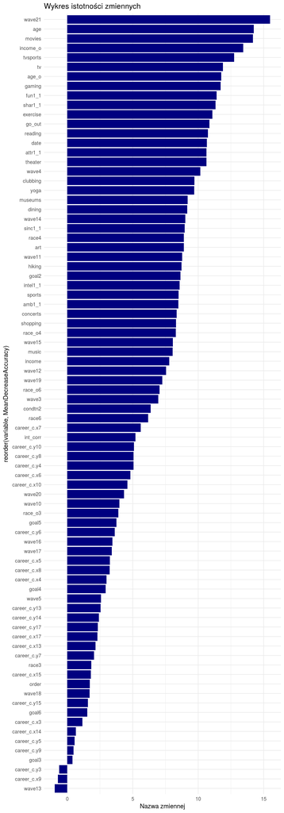

```r
importance(forest) %>%
    as.data.frame() %>%
    add_rownames(var = "variable") %>%
    ggplot(aes(reorder(variable, MeanDecreaseAccuracy), MeanDecreaseAccuracy)) +
    geom_bar(stat = 'identity', fill = 'navy') + coord_flip() + theme_minimal() +
   ylab("Nazwa zmiennej") + ggtitle("Wykres istotności zmiennych")
```

```r
class <- predict(forest, test.new, type = "class")
c3 <- check_class(test.new$dec, class)
c3
```

```
##  % popr. odp.       czułość      precyzja specyficzność
##     0.6979472     0.6285097     0.6799065     0.7109244
```

```r
forest.10 <- randomForest(as.factor(dec)~
                         clubbing + tvsports + age + movies + fun1_1 + age_o + go_out + tv + museums + date, data = train.new,
                       localImp = TRUE)
```

```r
class <- predict(forest.10, test.new, type = "class")
c4 <- check_class(test.new$dec, class)
c4
```

```
##  % popr. odp.       czułość      precyzja specyficzność
##     0.6441838     0.6069114     0.6069114     0.6750000
```

Jak widać, uzyskaliśmy gorsze wyniki od lasu losowego zbudowanego na wszystkich zmiennych.

Spórbujmy jeszcze zmienić parametry budowy drzewa:

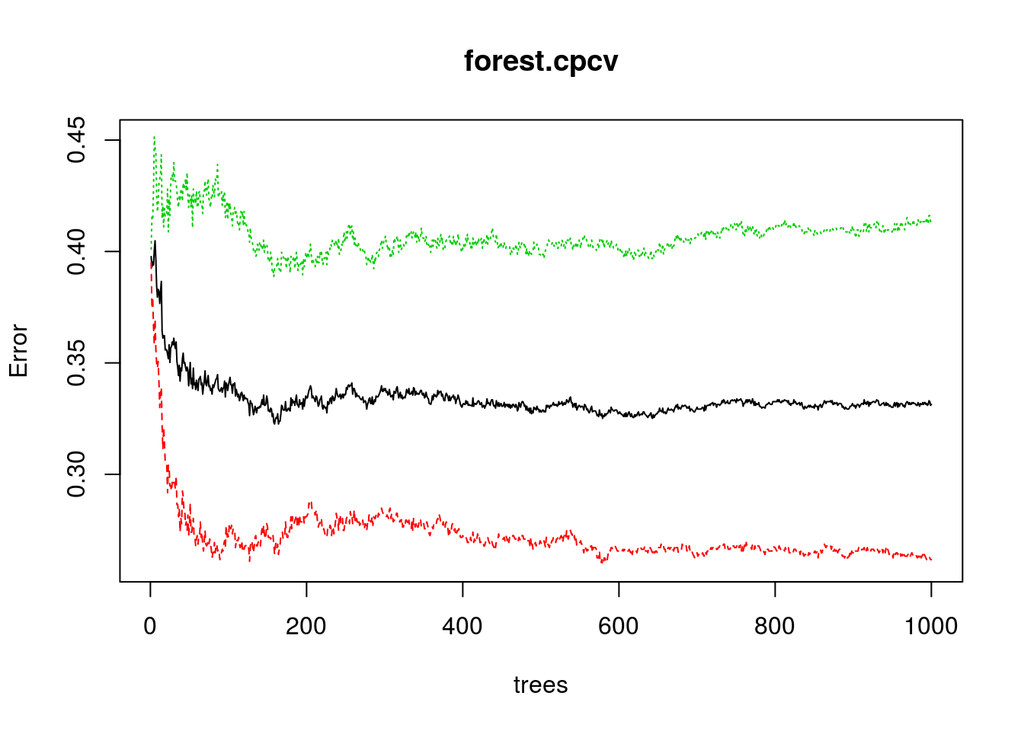

```r
forest.cpcv <- randomForest(as.factor(dec)~., data = train.new,
                       localImp = TRUE, cp = cp.cv, ntree = 1000)
plot(forest.cpcv)
```

```r
class <- predict(forest.cpcv, test.new, type = "class")
c5 <- check_class(test.new$dec, class)
c5
```

```
##  % popr. odp.       czułość      precyzja specyficzność
##     0.6989247     0.6263499     0.6823529     0.7107023
```

## RandomForestExplainer

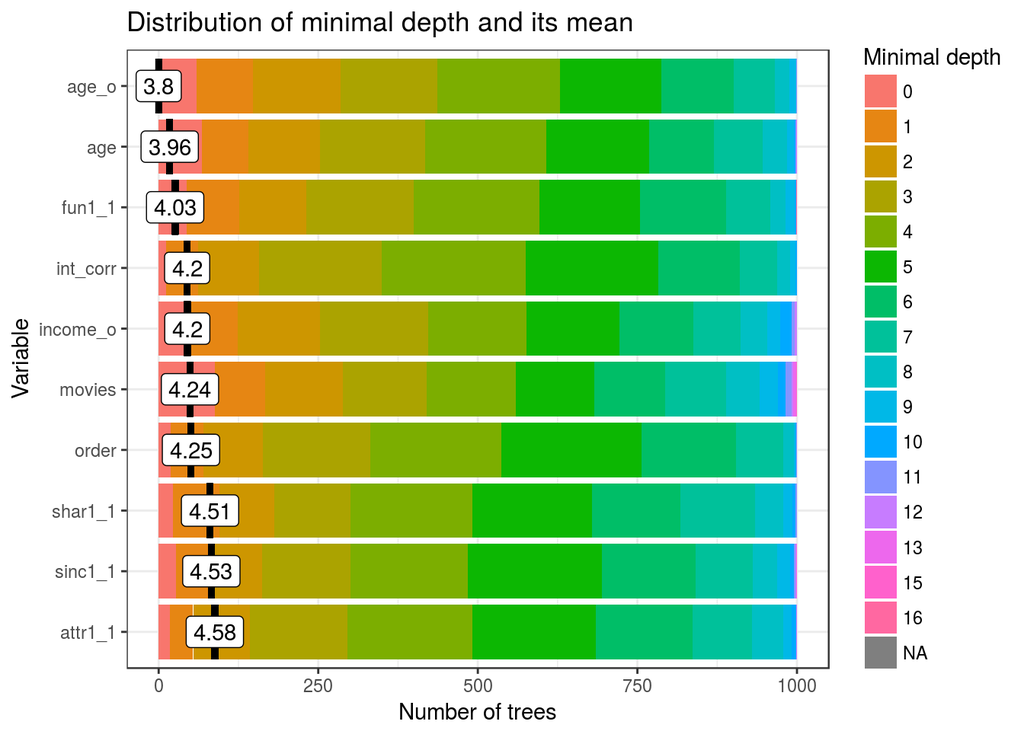

```r
min_depth_frame <- min_depth_distribution(forest)

plot_min_depth_distribution(min_depth_frame,
                            mean_sample = "relevant_trees")
```

```r
importance_frame <- measure_importance(forest)
```

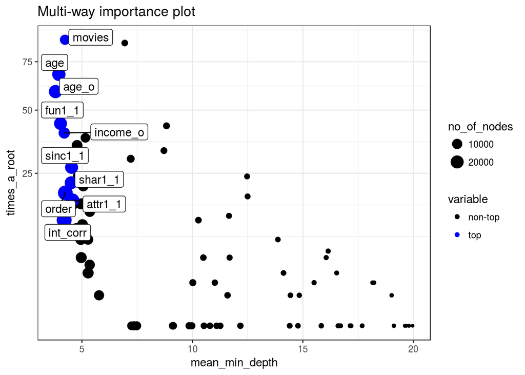

```r
plot_multi_way_importance(importance_frame,
                          size_measure = "no_of_nodes")
```

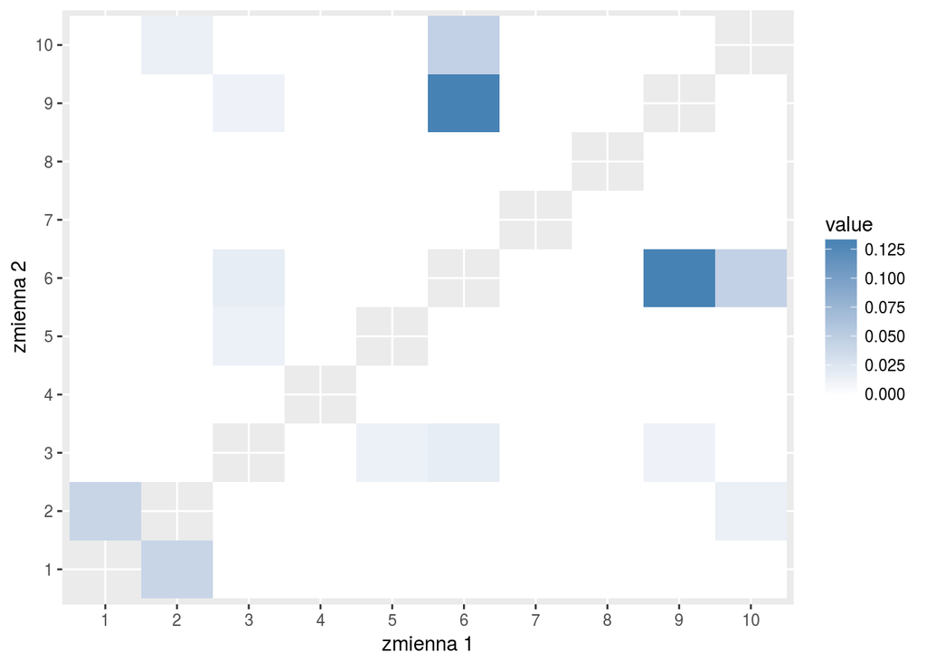

```r
forest_prox <- randomForest(as.factor(dec)~., data = train.new,
                       proximity = TRUE)
prox_subset <- forest_prox$proximity[1:10, 1:10] %>%
    as.data.frame()
prox_subset_melted <- prox_subset %>%
    reshape2::melt()

prox_subset_melted$variable2 <- rep(colnames(prox_subset), 10)
prox_subset_melted %>%
    filter(variable != variable2) %>%
    ggplot() + geom_tile(aes(factor(variable, colnames(prox_subset)),
                             factor(variable2, colnames(prox_subset)), fill = value)) +
    scale_fill_gradient(low = "white", high = "steelblue") +
    xlab("zmienna 1") + ylab("zmienna 2")
```

# XgBoost

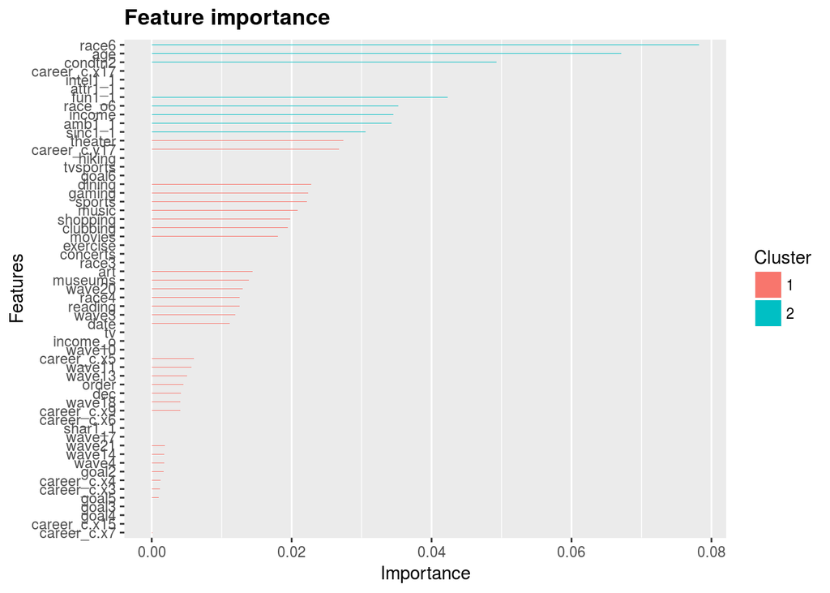

```r
param <- list(max_depth = 3, # maksymalna głębokość pojedynczego drzewa
              eta = 1, # wielkość kroku boostingu
              nthread = 2, # liczba wątków
              objective = "binary:logistic") # do wyboru także "binary:logistic"

nrounds <- 100 # maksymalna liczba iteracji
nfold <- 10 # liczba podzbiorów kroswalidacji
set.seed(44)


cv.res <- xgb.cv(data = as.matrix(train.new[,-1]), label = train.new[,1], nfold = nfold,
                 nrounds = nrounds, param = param, verbose = F)

optim_niter <- cv.res$evaluation_log$test_error_mean %>%
    which.min()

xg_model <- xgboost(data = as.matrix(train.new[,-1]),
                    label = train.new[,1],
                    verbose = FALSE,
                    nrounds = optim_niter,
                    params = list(max_depth = 5),
                    objective = "binary:logistic")

importance_matrix <- xgb.importance(colnames(train.new),
                                    model = xg_model)

xgb.ggplot.importance(importance_matrix)
```